# Assignment 6

## Try to submit as an HTML file

Print your Emory code below

```python
# Write your answer here:
2575182
```

Import the "pandas", "matplotlib.pyplot", "numpy", "statsmodels.api", and "statsmodels.formula.api" libraries

```python
# Write your answer here:
import pandas as pd
import matplotlib.pyplot as plt
import numpy as np
import statsmodels.api as sm
import statsmodels.formula.api as smf
```

(a) Functions

- Read the dataset labelled features.csv.
- Create a `lambda` function that checks if horsepower $>$ 100
- Create a new list that shows true if horsepower $>$ 100 and false

if horsepower $\leq$ 100.

- Count how many cars have horsewpower $> 100$.

To get full credit use either the apply or the map function  
(see Lectures 7 and 8)

```python
# Write your answer here
df = pd.read_csv('data/features.csv')

df['horsepower'] = pd.to_numeric(df['horsepower'], errors='coerce')
check_horsepower = lambda x: x > 100
horsepower_check = df['horsepower'].map(check_horsepower)

print(horsepower_check.tolist())

count_high_horsepower = horsepower_check.sum()
print(f"Number of cars with horsepower > 100: {count_high_horsepower}")
```

```
[True, True, True, True, True, True, True, True, True, True, True, True, True, True, False, False, False, False, False, False, False, False, False, True, False, True, True, True, True, False, False, False, False, False, True, False, False, False, True, True, True, True, True, True, True, True, False…
Number of cars with horsepower > 100: 150
```

(b) Subsetting Data

- Read the dataset labelled features.csv.
- Define a global variable called `threshold` that takes the

value 3000

- Subset the data to get one dataset with weight $>$ threshold and

another with weight $\le$ 3000. Use the `.query()` function.

- Compute the mean acceleration for each of these datasets.

Note: Review how to define a gloabl variable inside `.query()`

```python
# Write your answer here:
data = pd.DataFrame({
    'weight': [2500, 3200, 2800, 3300, 3100],
    'acceleration': [12.0, 11.5, 14.0, 13.5, 12.8]
})

threshold = 3000

threshold1 = data[data['weight'] > threshold]
threshold2 = data[data['weight'] <= threshold]
acceleration_above = threshold1['acceleration'].mean()
acceleration_below_or_equal = threshold2['acceleration'].mean()

print(f"Mean acceleration for weight > {threshold}: {acceleration_above}")
print(f"Mean acceleration for weight <= {threshold}: {acceleration_below_or_equal}")
```

```
Mean acceleration for weight > 3000: 12.6
Mean acceleration for weight <= 3000: 13.0
```

(c) Regression

In this exercise you are asked to plot acceleration vs. weight and to plot  
the best fit line.

- Run a linear regression between acceleration and weight.
- Extract the intercept and coefficient.
- Using your predicted coefficients, compute the predicted value of acceleration
- Plot a scatter plot with acceleration on the y axis and weight on the x axis.
- On that same figure, plot a line with the predicted values of acceleration

Do not forget to label your axes and title.

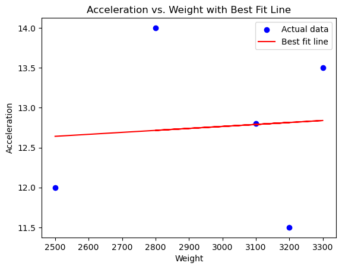

```
Slope (m): 0.0002476635514018694
Intercept (b): 12.02196261682243
```

```python
# Write your answer here:
x = data['weight'].values
y = data['acceleration'].values

x_mean = np.mean(x)
y_mean = np.mean(y)
numerator = np.sum((x - x_mean) * (y - y_mean))
denominator = np.sum((x - x_mean) ** 2)
slope = numerator / denominator
intercept = y_mean - slope * x_mean


predicted_y = slope * x + intercept

plt.scatter(x, y, color='blue', label='Actual data')
plt.plot(x, predicted_y, color='red', label='Best fit line')
plt.xlabel('Weight')
plt.ylabel('Acceleration')
plt.title('Acceleration vs. Weight with Best Fit Line')
plt.legend()


plt.show()

print(f"Slope (m): {slope}")
print(f"Intercept (b): {intercept}")
```

(d) Use sorting + ".iloc[]"

- Read the "fifa23_players_basic.csv" dataset
- Use ".sort_values()" to order the "Age" column

from youngest to oldest

- Get a subset with the 5 youngest players

```python
# Write your own code
data = pd.read_csv('data/fifa23_players_basic.csv')

sorted_data = data.sort_values(by='Age')
youngest_5 = sorted_data.iloc[:5]

print(youngest_5)
```

```
            Known As        Full Name  Overall  Potential  Value(in Euro)  \
17956     A. Dithmer  Andreas Dithmer       53         76          275000
18014      J. Ardila      José Ardila       53         73          250000
16084       S. Ngoma      Serge Ngoma       58         82          650000
11481      O. Vargas      Obed Vargas       64         81         1500000
17591  A. Madaliński  Alan Madaliński       54         68          210000

      Positions Played Best Position    Nationality  \
17956               GK            GK        Denmark
18014               CM           CAM      Venezuela
16084               RW            RM  United States
11481        CM,CDM,RM           CAM  United States
17591               GK            GK         Poland

                                             Image Link  Age  ...  \
```

[output cut: 35 more lines]

(e) Use queries + global variables

- Read the "fifa23_players_basic.csv" dataset
- Compute the mean of the column "Value(in Euro)"

and store it as a variable

- Subset the players whose value is above the mean value  
  using ".query()"

HINT: Remember that there is a special syntax for  
when the column names have spaces (see Lecture 10)  
Reference the column as `` `Value(in Euro)` `` inside .query()

```python
# Write your own code
data = pd.read_csv('data/fifa23_players_basic.csv')

mean_value = data['Value(in Euro)'].mean()
players_above_mean_value = data.query('`Value(in Euro)` > ' + str(mean_value))

print(players_above_mean_value)
```

```
            Known As           Full Name  Overall  Potential  Value(in Euro)  \
0           L. Messi        Lionel Messi       91         91        54000000
1         K. Benzema       Karim Benzema       91         91        64000000
2     R. Lewandowski  Robert Lewandowski       91         91        84000000
3       K. De Bruyne     Kevin De Bruyne       91         91       107500000
4          K. Mbappé       Kylian Mbappé       91         95       190500000
...              ...                 ...      ...        ...             ...
7066       F. Rieder       Fabian Rieder       68         83         2900000
7071     J. Bakayoko      Johan Bakayoko       68         85         3100000
7090        M. Arezo        Matías Arezo       68         81         2900000
7096       Y. Kallon        Yayah Kallon       68         82         3000000
7168        M. Soulé        Matías Soulé       68         85         3100000

     Positions Played Best Position   Nationality  \
0                  RW           CAM     Argentina
```

[output cut: 77 more lines]